# AnZ

- input - aaaabbccca
- output - 4a2b3c1a

```python
s_in = 'aaaabbccca'
s_out = ''
c = 1
for i in range(len(s_in)-1):
    if s_in[i] == s_in[i+1]:
        c=c+1
    else:
        s_out=s_out+str(c)+s_in[i]
        c = 1
s_out=s_out+str(c)+s_in[i+1]
print(s_out)
```

```
4a2b3c1a
```

**Write a python code for recognizing if entries to a list have the same characters or not?**

```python
l = ['same', 'different', 'same']
ele = l[0]
flag = 0
for i in l:
    if i != ele:
        flag = 1
        break
if flag==1: print('different')
else: print('same')
```

```
different
```

**You have an array of integers and you want to find a certain element?**

```python
a = [4,2,5,7,42,35,108]
ele = 42
flag = 0
for i in a:
    if i == ele:
        flag = 1
        break
if flag==1: print('found')
else: print('not found')
```

```
found
```

**You have an sorted array of integers and you want to find a certain element?**

```python
def binary_search(arr,start,end,val):
    if start<=end:
        mid = int((start+end)/2)
        if arr[mid] < val: return binary_search(arr, mid+1, end, val)
        elif arr[mid] > val: return binary_search(arr, start, mid-1, val)
        else: return 1
    else: return 0
```

```python
a = [2,4,5,7,35,42,108]
ele = 42
flag = binary_search(a,0,len(a),ele)
if flag==1: print('found')
else: print('not found')
```

```
found
```

**For a long sorted list and a short (4 element) sorted list, what algorithm would you use to search the long list for the 4 elements?**

```python
ll = [1,2,3,4,5,6,7,8,9,10]
sl = [0,2,3,5]
fl = []
for i in sl:
    for j in ll:
        if i==j:
            print(i,'\t found')
            break
```

```
2 	 found
3 	 found
5 	 found
```

**Given an unfair coin with the probability of heads not equal to .5, what algorithm could you use to create a list of random 1s and 0s?**

```python
def biased_coin(cnt,prob):
    lr = []
    for i in range(cnt):
        x = random.uniform(0, 1)
        if x>prob: lr.append('tail')
        else: lr.append('head')
    return(lr)
```

```python
import random
lr = biased_coin(10,.9)
lr
```

```
['head',
 'head',
 'head',
 'head',
 'head',
 'head',
 'head',
 'tail',
 'head',
 'head']
```

**If given an integer n and an array of numbers, give out the histogram divided into n bins**

```python
import matplotlib.pyplot as plt
plt.style.use('seaborn-white')
plt.rcParams['figure.figsize'] = 15,5
%matplotlib inline
```

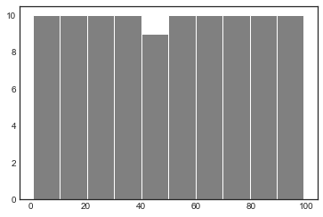

```python
a = range(1,100)
n = 10
plt.hist(a,n,edgecolor='white',color='gray');
```

**Write a Python function that displays the first n Fibonacci numbers**

```python
a = 0
b = 1
i = 0
n = 9
while i<n:
    print(i,"\t",a)
    i=i+1
    if i < n: print(i,"\t",b)
    i=i+1
    a = a+b
    b = b+a
```

```
0 	 0
1 	 1
2 	 1
3 	 2
4 	 3
5 	 5
6 	 8
7 	 13
8 	 21
```

**Given a bar plot, imagine you are pouring water from the top. How do you qualify how much water can be kept in the bar chart ?**

```python
barplot = [5,1,3,4]
water = []
for i in barplot:
    fill = max(0, min(barplot[0],barplot[-1]) - i)
    water.append(fill)
water
```

```
[0, 3, 1, 0]
```

```python
barplot = [5,3,1]
water = []
for i in barplot:
    fill = max(0, min(barplot[0],barplot[-1]) - i)
    water.append(fill)
water
```

```
[0, 0, 0]
```

**sort list**

```python
a = [108,4,2,5,7,42,35]
a.sort()
a
```

```
[2, 4, 5, 7, 35, 42, 108]
```

```python
a = [108,4,2,5,7,42,35]
for i in range(len(a)-1,0,-1):
    for j in range(i):
        if a[j]>a[j+1]:
            a[j],a[j+1] = a[j+1],a[j]
a
```

```
[2, 4, 5, 7, 35, 42, 108]
```

```python
str_list = ['The cat ate the fish', 'The cat saw the roses', 'The roses are red']
i = 0
out_dict={}
for j in str_list:
    out_dict[i] = j
    i=i+1
out_dict
```

```
{0: 'The cat ate the fish', 1: 'The cat saw the roses', 2: 'The roses are red'}
```